# **Project Foundations for Data Science: FoodHub Data Analysis**

#### Food Preparation Time

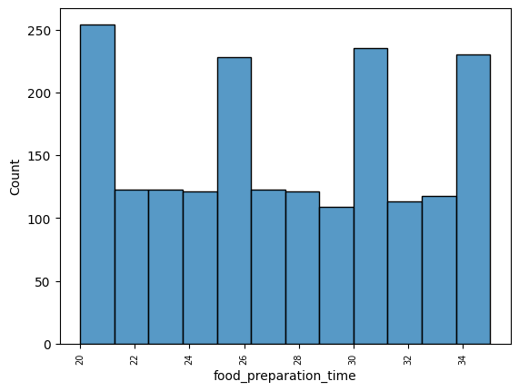

```python
#fig, ax = plt.subplots(figsize=(25, 10))
sns.histplot(data = df, x = 'food_preparation_time')
plt.xticks(rotation=90)
plt.xticks(fontsize=7)
plt.show()
```

As given in the graph above, time to prepare food takes a range of 20-21 minutes, or 25-26 minutes, or 30-31 minutes, or 34-35 minutes, for the most common time ranges. However the frequency of other time ranges between 20-35 minutes seems similar to one another but much below the frequency of the above former given common timings.

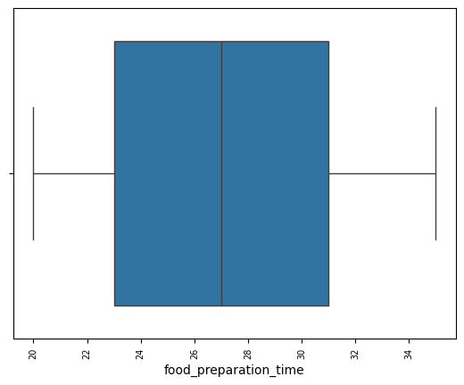

```python
sns.boxplot(data = df, x = 'food_preparation_time')
plt.xticks(rotation=90)
plt.xticks(fontsize=7)
plt.show()
```

#### Delivery Time

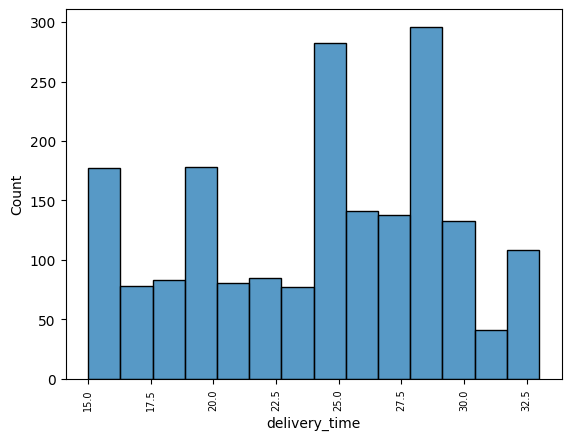

```python
#fig, ax = plt.subplots(figsize=(25, 10))
sns.histplot(data = df, x = 'delivery_time')
plt.xticks(rotation=90)
plt.xticks(fontsize=7)
plt.show()
```

As seen with the graph above, the common time for food delivery is approximately between 24-29 minutes.

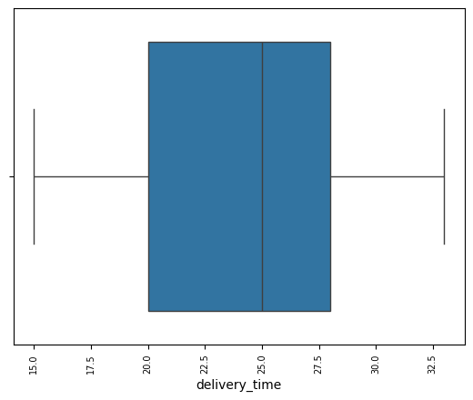

```python
sns.boxplot(data = df, x = 'delivery_time')
plt.xticks(rotation=90)
plt.xticks(fontsize=7)
plt.show()
```

With the box plot above for delivery time, it seems that there is a slight left skew with the median being on a slight right to the center of the box.

### **Question 7**: Which are the top 5 restaurants in terms of the number of orders received?

```python
top_5_restaurants = df['restaurant_name'].value_counts().head(5)
print("Top 5 restaurants with total number of orders:\n", top_5_restaurants)
```

```
Top 5 restaurants with total number of orders:
 restaurant_name
Shake Shack                  219
The Meatball Shop            132
Blue Ribbon Sushi            119
Blue Ribbon Fried Chicken     96
Parm                          68
Name: count, dtype: int64
```

### **Question 8**: Which is the most popular cuisine on weekends?

```python
weekend_data = df[df['day_of_the_week'].isin(['Weekend'])]
popular_cuisine_weekends = weekend_data['cuisine_type'].value_counts().head(1)
print(f"The most popular cuisine on weekends with total number of orders: {popular_cuisine_weekends}")
```

```
The most popular cuisine on weekends with total number of orders: cuisine_type
American    415
Name: count, dtype: int64
```

### **Question 9**: What percentage of the orders cost more than 20 dollars?

```python
orders_above_20 = (df['cost_of_the_order'] > 20).sum()
percentage_above_20 = (orders_above_20 / len(df['cost_of_the_order'])) * 100
print(f"Percentage of orders costing more than $20: {percentage_above_20}%")
```

```
Percentage of orders costing more than $20: 29.24130663856691%
```

### **Question 10**: What is the mean order delivery time?

```python
mean_delivery_time = df['delivery_time'].mean()
print(f"Mean order delivery time: {mean_delivery_time} minutes")
```

```
Mean order delivery time: 24.161749209694417 minutes
```

### **Question 11:** The company has decided to give 20% discount vouchers to the top 3 most frequent customers. Find the IDs of these customers and the number of orders they placed

```python
top_3_customers = df['customer_id'].value_counts().head(3)
print("Top 3 customers and their order counts:\n", top_3_customers)
```

```
Top 3 customers and their order counts:
 customer_id
52832    13
47440    10
83287     9
Name: count, dtype: int64
```

### **Question 12**: Perform a multivariate analysis to explore relationships between the important variables in the dataset. (It is a good idea to explore relations between numerical variables as well as relations between numerical and categorical variables)

#### Analysis between the realtionship between cuisines and food prep time

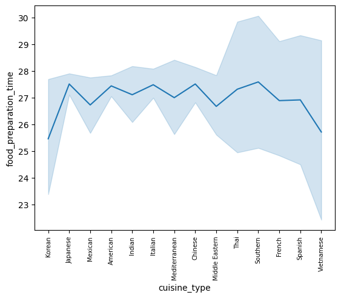

```python
import seaborn as sns
import matplotlib.pyplot as plt

# to create barchart between cuisines and food preparation time
sns.lineplot(data=df, x='cuisine_type', y='food_preparation_time')
plt.xticks(rotation=90)
plt.xticks(fontsize=7)
plt.show()
```

It seems like the popular dishes generally take about similar time to be prepared (American, Japanese, Italian). But it seems like there are cuisines that take lesser time too, and maybe that can be marketed properly so that the customers are more satisfied in terms of time taken for them to get their food.

#### Cuisine Type and Cost of the order

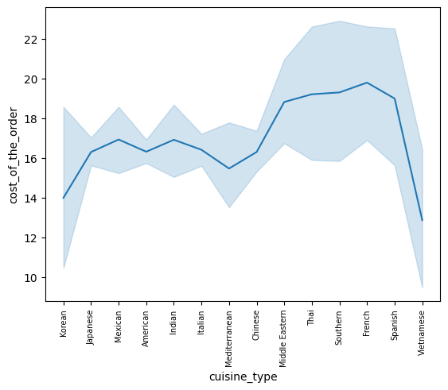

```python
sns.lineplot(data=df, x='cuisine_type', y='cost_of_the_order')
plt.xticks(rotation=90)
plt.xticks(fontsize=7)
plt.show()
```

#### Cuisine Types and Ratings

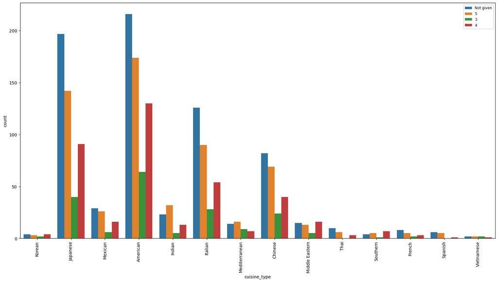

```python
plt.figure(figsize=(20, 10))
sns.countplot(data=df, x='cuisine_type', hue='rating')
plt.xticks(rotation=90)
#plt.xticks(fontsize=7)
plt.legend(loc='upper right', fontsize='small')
plt.show()
```

It seems like generally the number of no ratings given is higher than given ratings for all cuisine types except few.

#### Day and Cuisine Type

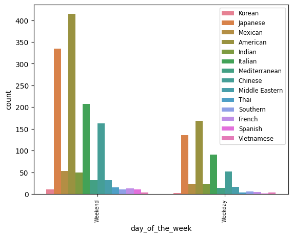

```python
sns.countplot(data=df, x='day_of_the_week', hue='cuisine_type')
plt.xticks(rotation=90)
plt.xticks(fontsize=7)
plt.legend(loc='upper right', fontsize='small')
plt.show()
```

The popularity seems similar for weekdays and weekends except for the scale, where the scale of orders overall reduce on weekdays compared to weekends.

#### Day of the week and Rating

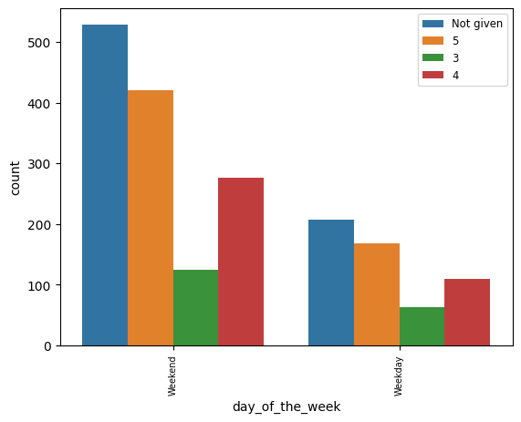

```python
sns.countplot(data=df, x='day_of_the_week', hue='rating')
plt.xticks(rotation=90)
plt.xticks(fontsize=7)
plt.legend(loc='upper right', fontsize='small')
plt.show()
```

It seems like there is a similar flow of pattern for rating overall as with the overall data, except the orders are lesser on weekdays compared to weekends

#### Cost and Food Preparation Time

[output not shown]

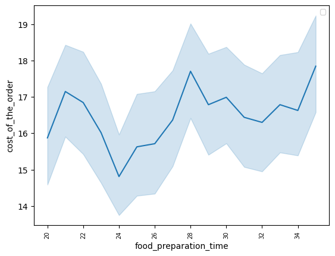

```python
sns.lineplot(data=df, x='food_preparation_time', y='cost_of_the_order')
plt.xticks(rotation=90)
plt.xticks(fontsize=7)
#plt.legend(loc='upper right', fontsize='small')
plt.show()
```

The preparation time varies with the cost but doesn't flow in a regular pattern with the increase in cost. I mean I was expecting the preparation time to increase with the increase in cost of the orders but it does not follow a regular pattern as such.

#### Overall look at the distribution of numerical variables

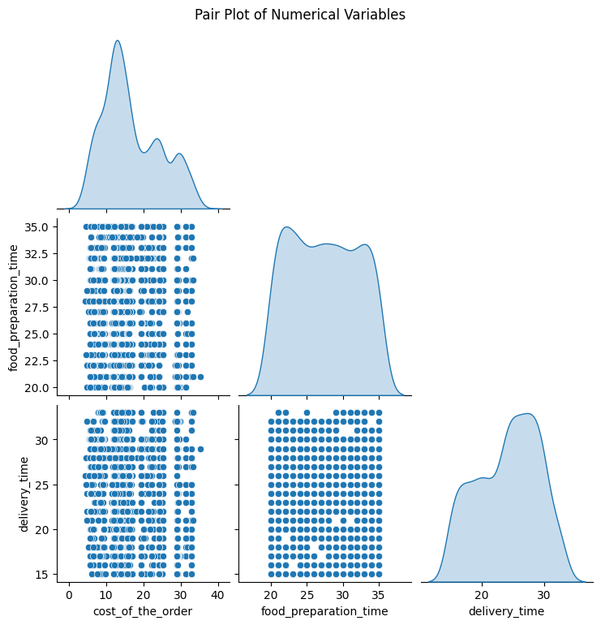

```python
import seaborn as sns
import matplotlib.pyplot as plt

df_cleaned = df.copy()
if 'Not given' in df_cleaned['rating'].values:
  df_cleaned = df_cleaned[df_cleaned['rating'] != 'Not given']

# Select numerical columns for the pair plot
numerical_columns = ['cost_of_the_order', 'food_preparation_time', 'delivery_time']

# Create the pair plot
sns.pairplot(df_cleaned[numerical_columns], diag_kind='kde', corner=True)
plt.suptitle("Pair Plot of Numerical Variables", y=1.02)  # Adjust title position
plt.show()
```

As shown in the graph above, Cost of the order seems to follow an almost normal distribution with a right skew, while delivery time seems to be left-skewed and food preparation time seems to be almost uniform distribution.

#### To understand interrelationship between variables using correlation matrix

[figure not shown]

```python
df_cleaned = df.copy()
if 'Not given' in df_cleaned['rating'].values:
  df_cleaned = df_cleaned[df_cleaned['rating'] != 'Not given']

# Selecting only numerical columns
numerical_df = df_cleaned.select_dtypes(include='number').drop(columns=['order_id', 'customer_id'])

# Correlation heatmap
plt.figure(figsize=(10, 8))
sns.heatmap(numerical_df.corr(), annot=True, cmap='coolwarm', fmt=".2f")
plt.title("Correlation Heatmap of Numerical Variables")
plt.show()
```

### **Question 13:** The company wants to provide a promotional offer in the advertisement of the restaurants. The condition to get the offer is that the restaurants must have a rating count of more than 50 and the average rating should be greater than 4. Find the restaurants fulfilling the criteria to get the promotional offer

```python
df_cleaned = df.copy()
if 'Not given' in df_cleaned['rating'].values:
  df_cleaned = df_cleaned[df_cleaned['rating'] != 'Not given']  # Remove rows with 'Not given

df_cleaned['rating_numeric'] = pd.to_numeric(df_cleaned['rating'], errors='coerce')  # Convert ratings to numeric

restaurant_stats = df_cleaned.groupby('restaurant_name').agg(
    rating_count=('rating', 'count'),
    avg_rating=('rating_numeric', 'mean')
).reset_index()

eligible_restaurants = restaurant_stats[(restaurant_stats['rating_count'] > 50) & (restaurant_stats['avg_rating'] > 4)]
print(eligible_restaurants)
```

```
               restaurant_name  rating_count  avg_rating
16   Blue Ribbon Fried Chicken            64    4.328125
17           Blue Ribbon Sushi            73    4.219178
117                Shake Shack           133    4.278195
132          The Meatball Shop            84    4.511905
```

### **Question 14:** The company charges the restaurant 25% on the orders having cost greater than 20 dollars and 15% on the orders having cost greater than 5 dollars. Find the net revenue generated by the company across all orders

```python
def calculate_revenue(row):
    if row['cost_of_the_order'] > 20:
        return 0.25 * row['cost_of_the_order']
        #print(f"Revenue generated from orders greater than 20 dollars: {0.25 * row['cost_of_the_order']}")
    elif row['cost_of_the_order'] > 5:
        return 0.15 * row['cost_of_the_order']
       # print(f"Revenue generated from orders greater than 5 dollars: {0.15 * row['cost_of_the_order']}")
    else:
        return 0

df['revenue'] = df.apply(calculate_revenue, axis=1)
total_revenue = df['revenue'].sum()
print(f'The total revenue of the company across all orders totals to be {total_revenue} dollars.')

#if row['cost_of_the_order'] > 20:
 #       print(f"Revenue generated from orders greater than 20 dollars: {0.25 * row['cost_of_the_order']}")
#elif row['cost_of_the_order'] > 5:
 #       print(f"Revenue generated from orders greater than 5 dollars: {0.15 * row['cost_of_the_order']}")
#else:
 # print(0)
```

```
The total revenue of the company across all orders totals to be 6166.303 dollars.
```

### **Question 15:** The company wants to analyze the total time required to deliver the food. What percentage of orders take more than 60 minutes to get delivered from the time the order is placed? (The food has to be prepared and then delivered)

```python
df['total_time'] = df['food_preparation_time'] + df['delivery_time']
orders_above_60 = (df['total_time'] > 60).sum()
percentage_above_60 = (orders_above_60 / len(df)) * 100
print(f'The percentage of orders that take more than 60 minutes to be delivered is {percentage_above_60} %.')
```

```
The percentage of orders that take more than 60 minutes to be delivered is 10.537407797681771 %.
```

### **Question 16:** The company wants to analyze the delivery time of the orders on weekdays and weekends. How does the mean delivery time vary during weekdays and weekends?

```python
df['day_type'] = df['day_of_the_week'].apply(
    lambda x: 'Weekend' if x in ['Weekend'] else 'Weekday'
)
mean_delivery_time_by_day_type = df.groupby('day_type')['delivery_time'].mean()
diff = mean_delivery_time_by_day_type['Weekday'] - mean_delivery_time_by_day_type['Weekend']
print(f'The mean delivery times for weekdays and weekends are given below {mean_delivery_time_by_day_type}.')
print(f'The difference between the mean delivery time during weekdays and weekends (Weekday-Weekend) is {diff}.')
```

```
The mean delivery times for weekdays and weekends are given below day_type
Weekday    28.340037
Weekend    22.470022
Name: delivery_time, dtype: float64.
The difference between the mean delivery time during weekdays and weekends (Weekday-Weekend) is 5.870014357297798.
```